# Doodle_challenge_v2

```python
import pandas as pd
import datetime as dt
import time
from datetime import datetime
import math
import numpy as np
import matplotlib
from matplotlib import axes
import matplotlib.pyplot as plt
import matplotlib.ticker as ticker
import seaborn as sns
import tarfile
import os
```

### Accessing the csv file within the .tar.gz file

To enable reproducibility without having to manually download just the tar.gz 1) clone the hiring-challenges repository from git bash (git clone https://github.com/DoodleScheduling/hiring-challenges.git) 2) store the absolute path of the '.tar.gz' file in a variable 3) extract that variable(tar.gz) file 4) Saving the corresponding csv file in a pandas dataframe

```python
tar_path = os.path.abspath(r'adventure_works_purchase_orders.tar.gz')
tar = tarfile.open(tar_path,
                   mode='r')
tar.extractall()
tar.close()
df_1 = pd.read_csv('adventure_works_purchase_orders.csv')
```

```python
df_1.head(5)
```

|  | SalesOrderNumber | OrderDate | DueDate | ShipDate | Sales_Person | Sales_Region | Sales_Province | Sales_City | Sales_Postal_Code | Customer_Code | ... | LineItem_Id | Product_Category | Product_Sub_Category | Product_Name | Product_Code | Unit_Cost | UnitPrice | UnitPriceDiscount | OrderQty | Unit_Freight_Cost |
| --- | --- | --- | --- | --- | --- | --- | --- | --- | --- | --- | --- | --- | --- | --- | --- | --- | --- | --- | --- | --- | --- |
| 0 | SO43659 | 7/1/05 | 00:00.0 | 00:00.0 | Tsvi Reiter | United States | Tennessee | Memphis | 38103 | AW00029825 | ... | 1 | Bikes | Mountain Bikes | Mountain-100 Black, 42 | BK-M82B-42 | 1898.0944 | 3374.99 | 0.0 | 1 | 51.3415 |
| 1 | SO43659 | 7/1/05 | 00:00.0 | 00:00.0 | Tsvi Reiter | United States | Tennessee | Memphis | 38103 | AW00029825 | ... | 2 | Bikes | Mountain Bikes | Mountain-100 Black, 44 | BK-M82B-44 | 1898.0944 | 3374.99 | 0.0 | 3 | 51.3415 |
| 2 | SO43659 | 7/1/05 | 00:00.0 | 00:00.0 | Tsvi Reiter | United States | Tennessee | Memphis | 38103 | AW00029825 | ... | 3 | Bikes | Mountain Bikes | Mountain-100 Black, 48 | BK-M82B-48 | 1898.0944 | 3374.99 | 0.0 | 1 | 51.3415 |
| 3 | SO43659 | 7/1/05 | 00:00.0 | 00:00.0 | Tsvi Reiter | United States | Tennessee | Memphis | 38103 | AW00029825 | ... | 4 | Bikes | Mountain Bikes | Mountain-100 Silver, 38 | BK-M82S-38 | 1912.1544 | 3399.99 | 0.0 | 1 | 51.3415 |
| 4 | SO43659 | 7/1/05 | 00:00.0 | 00:00.0 | Tsvi Reiter | United States | Tennessee | Memphis | 38103 | AW00029825 | ... | 5 | Bikes | Mountain Bikes | Mountain-100 Silver, 42 | BK-M82S-42 | 1912.1544 | 3399.99 | 0.0 | 1 | 51.3415 |

5 rows × 25 columns

```python
### Looking at all columns
df_1.columns
```

```
Index(['SalesOrderNumber', 'OrderDate', 'DueDate', 'ShipDate', 'Sales_Person',
       'Sales_Region', 'Sales_Province', 'Sales_City', 'Sales_Postal_Code',
       'Customer_Code', 'Customer_Name', 'Customer_Region',
       'Customer_Province', 'Customer_City', 'Customer_Postal_Code',
       'LineItem_Id', 'Product_Category', 'Product_Sub_Category',
       'Product_Name', 'Product_Code', 'Unit_Cost', 'UnitPrice',
       'UnitPriceDiscount', 'OrderQty', 'Unit_Freight_Cost'],
      dtype='object')
```

```python
## Naming conventions are not clear and uniform (i.e UnitPriceDiscount, Customer_Region)
## simplifying them by removing capitalized letters
```

```python
df_1 = df_1.rename(columns = {'SalesOrderNumber':'sales_order_number', 'OrderDate':'order_date',
                     'DueDate':'due_date', 'ShipDate':'ship_date', 'Sales_Person':'sales_person',
                     'Sales_Region':'sales_region', 'Sales_Province':'sales_province', 'Sales_City':'sales_city',
                     'Sales_Postal_Code':'sales_postal_code', 'Customer_Code':'customer_code', 'Customer_Name':'customer_name',
                     'Customer_Region':'customer_region','Customer_Province':'customer_province',
                     'Customer_City':'customer_city', 'Customer_Postal_Code':'customer_postal_code',
                     'LineItem_Id':'line_item_id', 'Product_Category':'product_category',
                     'Product_Sub_Category':'product_sub_category',
                     'Product_Name':'product_name', 'Product_Code':'product_code', 'Unit_Cost':'unit_cost',
                     'UnitPrice':'unit_price', 'UnitPriceDiscount':'unit_price_discount', 'OrderQty':'order_qty',
                     'Unit_Freight_Cost':'unit_freight_cost', })

## There should be an automatic way to
### a) insert '_' before second capital letter in a word
### b) make all column names lower case without doing them one by one
```

```python
df_1.columns
```

```
Index(['sales_order_number', 'order_date', 'due_date', 'ship_date',
       'sales_person', 'sales_region', 'sales_province', 'sales_city',
       'sales_postal_code', 'customer_code', 'customer_name',
       'customer_region', 'customer_province', 'customer_city',
       'customer_postal_code', 'line_item_id', 'product_category',
       'product_sub_category', 'product_name', 'product_code', 'unit_cost',
       'unit_price', 'unit_price_discount', 'order_qty', 'unit_freight_cost'],
      dtype='object')
```

```python
### Relevant columns by dimension for future reference
product_details = ['product_category', 'product_sub_category','product_name', 'product_code']
customer_details = ['customer_code', 'customer_name', 'customer_region', 'customer_province',
                    'customer_city', 'customer_postal_code']
sales_details = ['sales_person', 'sales_region', 'sales_province', 'sales_city', 'sales_postal_code']
order_details = ['sales_order_number', 'order_date', 'due_date', 'ship_date', 'line_item_id']
unit_econ_details = ['line_item_id', 'unit_cost', 'unit_price', 'unit_price_discount', 'order_qty', 'unit_freight_cost']
```

```python
pd.DataFrame(index = df_1.columns
            ,data= {'data_type': df_1.dtypes.values,'missing_values': df_1.isna().sum(),
                    'null_values':df_1.isnull().sum(), 'unique_values':df_1.nunique()}\
            ).sort_values(by = 'missing_values', ascending=False)
```

|  | data_type | missing_values | null_values | unique_values |
| --- | --- | --- | --- | --- |
| sales_order_number | object | 0 | 0 | 2629 |
| customer_city | object | 0 | 0 | 318 |
| order_qty | int64 | 0 | 0 | 41 |
| unit_price_discount | float64 | 0 | 0 | 9 |
| unit_price | float64 | 0 | 0 | 82 |
| unit_cost | float64 | 0 | 0 | 143 |
| product_code | object | 0 | 0 | 249 |
| product_name | object | 0 | 0 | 249 |
| product_sub_category | object | 0 | 0 | 33 |
| product_category | object | 0 | 0 | 4 |
| line_item_id | int64 | 0 | 0 | 41884 |
| customer_postal_code | object | 0 | 0 | 331 |
| customer_province | object | 0 | 0 | 47 |
| order_date | object | 0 | 0 | 37 |
| customer_region | object | 0 | 0 | 3 |
| customer_name | object | 0 | 0 | 420 |
| customer_code | object | 0 | 0 | 422 |
| sales_postal_code | int64 | 0 | 0 | 12 |
| sales_city | object | 0 | 0 | 12 |
| sales_province | object | 0 | 0 | 10 |
| sales_region | object | 0 | 0 | 3 |
| sales_person | object | 0 | 0 | 12 |
| ship_date | object | 0 | 0 | 1 |
| due_date | object | 0 | 0 | 1 |
| unit_freight_cost | float64 | 0 | 0 | 2308 |

From this overview we can understand the follwing: -) line_item_id is the one column with all unique values -) 249 different products best differentiated by code. No two products with same code (249 codes and product names) -) 3 Sales Regions, 10 Sales Provinces, 12 Sales Cities

### Handling datetime columns

```python
print(df_1['order_date'].dtypes)
df_1['order_date'].drop_duplicates()
## format seems to be m/d/y
```

```
object
```

```
0         7/1/05
267       8/1/05
864       9/1/05
1352     10/1/05
1718     11/1/05
2603     12/1/05
3246      1/1/06
3526      2/1/06
4208      3/1/06
4733      4/1/06
5103      5/1/06
5980      6/1/06
6637      7/1/06
7889      8/1/06
10043     9/1/06
```

[output cut: 23 more lines]

```python
### Recoding the order date column
df_1['order_date_rec'] = pd.to_datetime(df_1['order_date'], format = '%m/%d/%y')
```

```python
df_1['order_year'] = df_1['order_date_rec'].dt.year
```

```python
## Need months to be two digits so sorting works properly in visualizations
df_1['order_month'] = df_1['order_year'].astype(str)+ '-' +\
                df_1['order_date_rec'].dt.month.apply(lambda x: '{0:0>2}'.format(x)).astype(str)
df_1['order_month_no'] = df_1['order_date_rec'].dt.month
```

```python
df_1[['order_date','order_month', 'order_year']].drop_duplicates()
```

|  | order_date | order_month | order_year |
| --- | --- | --- | --- |
| 0 | 7/1/05 | 2005-07 | 2005 |
| 267 | 8/1/05 | 2005-08 | 2005 |
| 864 | 9/1/05 | 2005-09 | 2005 |
| 1352 | 10/1/05 | 2005-10 | 2005 |
| 1718 | 11/1/05 | 2005-11 | 2005 |
| 2603 | 12/1/05 | 2005-12 | 2005 |
| 3246 | 1/1/06 | 2006-01 | 2006 |
| 3526 | 2/1/06 | 2006-02 | 2006 |
| 4208 | 3/1/06 | 2006-03 | 2006 |
| 4733 | 4/1/06 | 2006-04 | 2006 |
| 5103 | 5/1/06 | 2006-05 | 2006 |
| 5980 | 6/1/06 | 2006-06 | 2006 |
| 6637 | 7/1/06 | 2006-07 | 2006 |
| 7889 | 8/1/06 | 2006-08 | 2006 |
| 10043 | 9/1/06 | 2006-09 | 2006 |
| 11603 | 10/1/06 | 2006-10 | 2006 |
| 12614 | 11/1/06 | 2006-11 | 2006 |
| 14361 | 12/1/06 | 2006-12 | 2006 |
| 15609 | 1/1/07 | 2007-01 | 2007 |
| 16299 | 2/1/07 | 2007-02 | 2007 |
| 17565 | 3/1/07 | 2007-03 | 2007 |
| 18446 | 4/1/07 | 2007-04 | 2007 |
| 19491 | 5/1/07 | 2007-05 | 2007 |
| 21203 | 6/1/07 | 2007-06 | 2007 |
| 22407 | 7/1/07 | 2007-07 | 2007 |
| 23806 | 8/1/07 | 2007-08 | 2007 |
| 26303 | 9/1/07 | 2007-09 | 2007 |
| 28541 | 10/1/07 | 2007-10 | 2007 |
| 29694 | 11/1/07 | 2007-11 | 2007 |
| 31664 | 12/1/07 | 2007-12 | 2007 |
| 33450 | 1/1/08 | 2008-01 | 2008 |
| 34336 | 2/1/08 | 2008-02 | 2008 |
| 35757 | 3/1/08 | 2008-03 | 2008 |
| 37045 | 3/31/08 | 2008-03 | 2008 |
| 37046 | 4/1/08 | 2008-04 | 2008 |
| 38193 | 5/1/08 | 2008-05 | 2008 |
| 40118 | 6/1/08 | 2008-06 | 2008 |

```python
df_1.columns
```

```
Index(['sales_order_number', 'order_date', 'due_date', 'ship_date',
       'sales_person', 'sales_region', 'sales_province', 'sales_city',
       'sales_postal_code', 'customer_code', 'customer_name',
       'customer_region', 'customer_province', 'customer_city',
       'customer_postal_code', 'line_item_id', 'product_category',
       'product_sub_category', 'product_name', 'product_code', 'unit_cost',
       'unit_price', 'unit_price_discount', 'order_qty', 'unit_freight_cost',
       'order_date_rec', 'order_year', 'order_month', 'order_month_no'],
      dtype='object')
```

```python
print(df_1['ship_date'].drop_duplicates())
print(df_1['due_date'].drop_duplicates())
```

```
0    00:00.0
Name: ship_date, dtype: object
0    00:00.0
Name: due_date, dtype: object
```

```python
## Removing the columns DueDate and ShipDate as they are redundant with only one non-telling values
df_1 = df_1.drop(columns = ['due_date', 'ship_date'])
```

```python
## We can get Order Price by multiplying Order Qty and Unit Price
df_1['order_price'] = df_1['order_qty'] * df_1['unit_price']
df_1['order_cost'] = df_1['order_qty'] * df_1['unit_cost']
df_1['order_freight_cost'] = df_1['order_qty'] * df_1['unit_freight_cost']
```

```python
df_1['unit_price_discount'].drop_duplicates()
## Quite possibly seems to be % discounts from the format
```

```
0        0.00
511      0.02
550      0.05
725      0.10
5981     0.35
6768     0.30
20394    0.15
22638    0.20
38206    0.40
Name: unit_price_discount, dtype: float64
```

```python
## Is the discount already included in the price - finding an example
df_1['product_name'].loc[df_1['unit_price_discount']>0].drop_duplicates()
```

```
511      Mountain-100 Silver, 44
513       Mountain-100 Black, 38
550       Mountain Bike Socks, M
584      Mountain-100 Silver, 42
1010      Mountain-100 Black, 44
                  ...
38306    Mountain-500 Silver, 40
38310    Mountain-500 Silver, 44
38311    Mountain-500 Silver, 48
38337    Mountain-500 Silver, 42
40084    LL Mountain Seat/Saddle
Name: product_name, Length: 121, dtype: object
```

```python
example = 'Mountain-100 Silver, 44'
```

```python
df_1[['product_name','unit_price', 'unit_price_discount']].loc[df_1['product_name']==example].drop_duplicates()
```

|  | product_name | unit_price | unit_price_discount |
| --- | --- | --- | --- |
| 5 | Mountain-100 Silver, 44 | 3399.99 | 0.00 |
| 511 | Mountain-100 Silver, 44 | 3399.99 | 0.02 |
| 5984 | Mountain-100 Silver, 44 | 3399.99 | 0.35 |

We can see that the Unit Price remains the same regardless of the discount. Hence we don't have the final price for the good. We can obtain the final price as below by removing the (assumingly) % discount from the UnitPrice

```python
df_1['unit_final_price'] = (df_1['unit_price']*(1-df_1['unit_price_discount'])).round(2)
df_1['final_order_price'] = df_1['order_qty'] * df_1['unit_final_price']
```

```python
## Calculating Unit and Order margins

### Unit Margins
## Margin I includes granted Discount but not the Freight Cost
df_1['unit_margin_1'] = df_1['unit_final_price'] - df_1['unit_cost']
df_1['unit_cm1%'] = df_1['unit_margin_1']/df_1['unit_final_price']

## Margin II includes Discount and Freight Cost
df_1['unit_margin_2'] = df_1['unit_margin_1']- df_1['unit_freight_cost']
df_1['unit_cm2_%'] = df_1['unit_margin_2']/df_1['unit_final_price']

### Order Margins
df_1['order_margin_1'] = df_1['final_order_price'] - df_1['order_cost']
df_1['order_cm1%'] = df_1['order_margin_1']/df_1['final_order_price']

df_1['order_margin_2'] = df_1['order_margin_1'] - df_1['order_freight_cost']
df_1['order_cm2%'] = df_1['order_margin_2']/df_1['final_order_price']
```

```python
df_1[['order_margin_2', 'order_price', 'order_cm2%']].drop_duplicates()
```

|  | order_margin_2 | order_price | order_cm2% |
| --- | --- | --- | --- |
| 0 | 1425.554100 | 3374.99 | 0.422388 |
| 1 | 4276.662300 | 10124.97 | 0.422388 |
| 3 | 1436.494100 | 3399.99 | 0.422500 |
| 5 | 2872.988200 | 6799.98 | 0.422500 |
| 7 | -119.531400 | 149.97 | -0.797035 |
| ... | ... | ... | ... |
| 41879 | 66.417300 | 528.10 | 0.125767 |
| 41880 | 375.699650 | 1349.60 | 0.278379 |
| 41881 | 1521.602600 | 5458.00 | 0.278784 |
| 41882 | -78.220800 | 161.97 | -0.482934 |
| 41883 | -289.144425 | 1694.97 | -0.284320 |

34735 rows × 3 columns

Contribution Margin I (CM I) is calculated by removing the COGS and the discount from the Final Revenue made Contribution Margin II (CM II) is calculated by additionally removing fulfillment costs, as are the freight costs

#### Sense-check for the final price calculation

```python
df_1[['product_name','unit_price', 'unit_price_discount',
      'unit_final_price', 'order_qty', 'final_order_price',
      'unit_margin_1', 'unit_margin_2',
      'order_margin_1', 'order_margin_2',
      'order_cm1%', 'order_cm2%']].loc[df_1['product_name']==example].drop_duplicates()
```

|  | product_name | unit_price | unit_price_discount | unit_final_price | order_qty | final_order_price | unit_margin_1 | unit_margin_2 | order_margin_1 | order_margin_2 | order_cm1% | order_cm2% |
| --- | --- | --- | --- | --- | --- | --- | --- | --- | --- | --- | --- | --- |
| 5 | Mountain-100 Silver, 44 | 3399.99 | 0.00 | 3399.99 | 2 | 6799.98 | 1487.8356 | 1436.4941 | 2975.6712 | 2872.9882 | 0.437600 | 0.422500 |
| 21 | Mountain-100 Silver, 44 | 3399.99 | 0.00 | 3399.99 | 1 | 3399.99 | 1487.8356 | 1396.2344 | 1487.8356 | 1396.2344 | 0.437600 | 0.410658 |
| 24 | Mountain-100 Silver, 44 | 3399.99 | 0.00 | 3399.99 | 1 | 3399.99 | 1487.8356 | 1444.8374 | 1487.8356 | 1444.8374 | 0.437600 | 0.424953 |
| 40 | Mountain-100 Silver, 44 | 3399.99 | 0.00 | 3399.99 | 1 | 3399.99 | 1487.8356 | 1442.0450 | 1487.8356 | 1442.0450 | 0.437600 | 0.424132 |
| 46 | Mountain-100 Silver, 44 | 3399.99 | 0.00 | 3399.99 | 2 | 6799.98 | 1487.8356 | 1441.9325 | 2975.6712 | 2883.8650 | 0.437600 | 0.424099 |
| ... | ... | ... | ... | ... | ... | ... | ... | ... | ... | ... | ... | ... |
| 6522 | Mountain-100 Silver, 44 | 3399.99 | 0.35 | 2209.99 | 5 | 11049.95 | 297.8356 | 188.4586 | 1489.1780 | 942.2930 | 0.134768 | 0.085276 |
| 6538 | Mountain-100 Silver, 44 | 3399.99 | 0.35 | 2209.99 | 5 | 11049.95 | 297.8356 | 198.7844 | 1489.1780 | 993.9220 | 0.134768 | 0.089948 |
| 6555 | Mountain-100 Silver, 44 | 3399.99 | 0.35 | 2209.99 | 2 | 4419.98 | 297.8356 | 249.6113 | 595.6712 | 499.2226 | 0.134768 | 0.112947 |
| 6598 | Mountain-100 Silver, 44 | 3399.99 | 0.35 | 2209.99 | 2 | 4419.98 | 297.8356 | 231.7435 | 595.6712 | 463.4870 | 0.134768 | 0.104862 |
| 6636 | Mountain-100 Silver, 44 | 3399.99 | 0.35 | 2209.99 | 2 | 4419.98 | 297.8356 | 218.2758 | 595.6712 | 436.5516 | 0.134768 | 0.098768 |

155 rows × 12 columns

#### CM2% in this case varies from 42% to 6% depending on the granted discounts

```python
## Discount will be in absolute values
df_1['order_discount'] = abs(df_1['final_order_price'] - df_1['order_price'])
```

```python
### Revenues by product categories
product_view = df_1.groupby('product_category').agg({'order_qty':'count', 'final_order_price':'sum', 'order_cost':'sum',
                                     'order_margin_1':'sum',
                                     'order_margin_2': 'sum'}).reset_index().sort_values(by = 'final_order_price',
                                                                                        ascending = False)
```

```python
## We can see that there is overall a difference in margins where bikes and components yield positive margins
## and clothing and accessories yield negative marigns
product_view[['final_order_price', 'order_margin_1', 'order_margin_2']]/1000
```

|  | final_order_price | order_margin_1 | order_margin_2 |
| --- | --- | --- | --- |
| 1 | 83414.92953 | 32030.998704 | 29160.716755 |
| 3 | 14174.65018 | 6091.190349 | 4623.530859 |
| 2 | 1951.74034 | 900.585375 | -670.163837 |
| 0 | 589.28247 | 355.217332 | -211.354740 |

```python
product_view['order_cm2%'] = product_view['order_margin_2']/product_view['final_order_price']
```

```python
product_view
```

|  | product_category | order_qty | final_order_price | order_cost | order_margin_1 | order_margin_2 | order_cm2% |
| --- | --- | --- | --- | --- | --- | --- | --- |
| 1 | Bikes | 17518 | 8.341493e+07 | 5.138393e+07 | 3.203100e+07 | 2.916072e+07 | 0.349586 |
| 3 | Components | 13018 | 1.417465e+07 | 8.083460e+06 | 6.091190e+06 | 4.623531e+06 | 0.326183 |
| 2 | Clothing | 8091 | 1.951740e+06 | 1.051155e+06 | 9.005854e+05 | -6.701638e+05 | -0.343367 |
| 0 | Accessories | 3257 | 5.892825e+05 | 2.340651e+05 | 3.552173e+05 | -2.113547e+05 | -0.358665 |

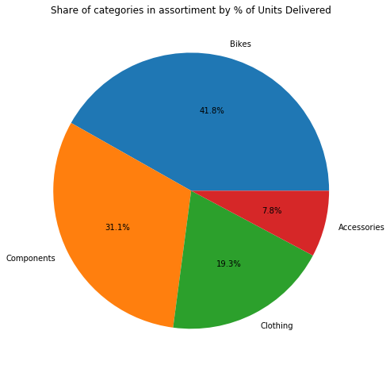

```python
plt.figure(figsize = (16,8))
plt.pie(product_view['order_qty'], labels = product_view['product_category'],
       autopct='%1.1f%%');
plt.title('Share of categories in assortiment by % of Units Delivered', fontsize = 12);
```

```python
## Changing some default matplotlib paramters
### Did this in retrospect after realizing the writing would be too small
matplotlib.rcParams['font.size'] = 12
def pie_plot(source_df, x_parameter, _labels, title):
    plt.figure(figsize = (16,8))
    plt.pie(source_df[x_parameter], labels = source_df[_labels],
           autopct='%1.1f%%');
    plt.title(title, fontsize = 12);
```

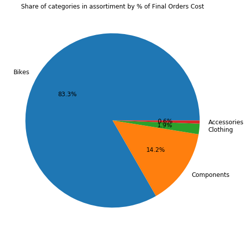

```python
pie_plot(product_view, 'final_order_price', 'product_category',
        'Share of categories in assortiment by % of Final Orders Cost')
```

#### Total Revenue and Total Cost by product tell a similar story that most of the company's cost and revenues are in the Bikes' section

##### For this purpose a recategorization of the product categories as below is done

```python
### Recategorizing products
## Creating a recategorization into Bikes and Extras (Accessories, Clothing, Components)
df_1['product_category_rec'] = np.where(df_1['product_category'].isin(['Clothing', 'Accessories', 'Components']),
                                        'Extras', 'Bikes')
```

#### Product sub categories by product category

```python
df_1[['product_category', 'product_sub_category']].drop_duplicates().sort_values(by = 'product_category',
                                                                                ascending = True)
```

|  | product_category | product_sub_category |
| --- | --- | --- |
| 22443 | Accessories | Bottles and Cages |
| 22433 | Accessories | Cleaners |
| 22432 | Accessories | Hydration Packs |
| 11 | Accessories | Helmets |
| 6719 | Accessories | Locks |
| 6671 | Accessories | Pumps |
| 22434 | Accessories | Bike Racks |
| 22570 | Accessories | Tires and Tubes |
| 22632 | Bikes | Touring Bikes |
| 0 | Bikes | Mountain Bikes |
| 12 | Bikes | Road Bikes |
| 6659 | Clothing | Shorts |
| 6662 | Clothing | Bib-Shorts |
| 6665 | Clothing | Gloves |
| 10 | Clothing | Caps |
| 22430 | Clothing | Vests |
| 9 | Clothing | Socks |
| 7 | Clothing | Jerseys |
| 6660 | Clothing | Tights |
| 22582 | Components | Brakes |
| 22613 | Components | Bottom Brackets |
| 22567 | Components | Derailleurs |
| 22563 | Components | Cranksets |
| 22576 | Components | Chains |
| 6855 | Components | Forks |
| 22419 | Components | Pedals |
| 6876 | Components | Headsets |
| 6648 | Components | Handlebars |
| 6646 | Components | Wheels |
| 43 | Components | Mountain Frames |
| 35 | Components | Road Frames |
| 22451 | Components | Saddles |
| 22840 | Components | Touring Frames |

```python
### Revenues by sub product categories
sub_product_view = df_1.groupby('product_sub_category').agg({'order_qty':'count', 'final_order_price':'sum', 'order_cost':'sum',
                                     'order_margin_1':'sum',
                                     'order_margin_2': 'sum'}).reset_index().sort_values(by = 'final_order_price',
                                                                                        ascending = False)
```

#### Bikes sub categories

Not looking at all subcategories altogether in a pie chart as it will be hard to notice anything beyond the main part occupied by bikes.

```python
bikes_sub_products = sub_product_view.loc[sub_product_view['product_sub_category'].str.contains(' Bikes')]
```

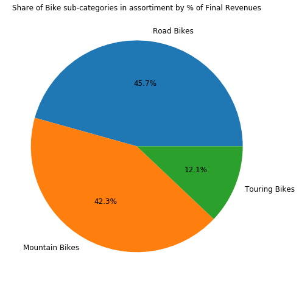

```python
pie_plot(bikes_sub_products, 'final_order_price', 'product_sub_category',
        'Share of Bike sub-categories in assortiment by % of Final Revenues')
```

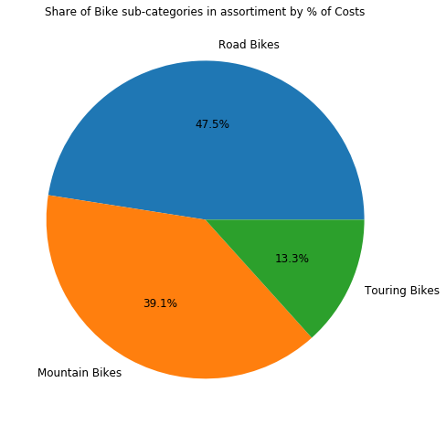

```python
pie_plot(bikes_sub_products, 'order_cost', 'product_sub_category',
        'Share of Bike sub-categories in assortiment by % of Costs')
```

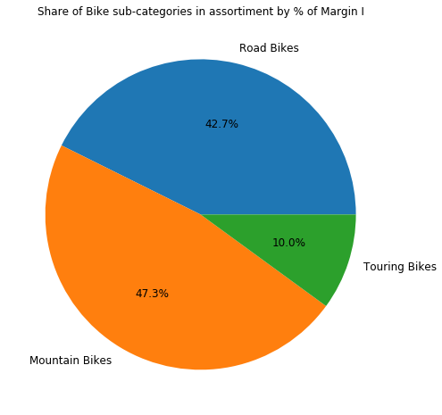

```python
pie_plot(bikes_sub_products, 'order_margin_1', 'product_sub_category',
        'Share of Bike sub-categories in assortiment by % of Margin I')
```

### Granular look at bikes

```python
### Revenues by sub product categories
```

```python
list(df_1['product_name'])
```

```
['Mountain-100 Black, 42',
 'Mountain-100 Black, 44',
 'Mountain-100 Black, 48',
 'Mountain-100 Silver, 38',
 'Mountain-100 Silver, 42',
 'Mountain-100 Silver, 44',
 'Mountain-100 Silver, 48',
 'Long-Sleeve Logo Jersey, M',
 'Long-Sleeve Logo Jersey, XL',
 'Mountain Bike Socks, M',
 'AWC Logo Cap',
 'Sport-100 Helmet, Blue',
 'Road-650 Red, 44',
 'Road-450 Red, 52',
 'Road-650 Red, 60',
 'Mountain-100 Silver, 42',
 'Mountain-100 Black, 38',
 'Long-Sleeve Logo Jersey, M',
 'Long-Sleeve Logo Jersey, XL',
 'Mountain-100 Black, 44',
 'Mountain-100 Silver, 38',
 'Mountain-100 Silver, 44',
 'Mountain-100 Black, 48',
 'Sport-100 Helmet, Blue',
 'Mountain-100 Silver, 44',
 'Sport-100 Helmet, Red',
 'Long-Sleeve Logo Jersey, L',
 'Mountain-100 Black, 44',
 'AWC Logo Cap',
 'Mountain-100 Black, 38',
 'Mountain-100 Black, 48',
 'Mountain Bike Socks, M',
 'Mountain-100 Black, 42',
 'Road-650 Red, 52',
 'Road-150 Red, 56',
 'ML Road Frame - Red, 48',
 'Road-450 Red, 44',
 'Road-650 Black, 44',
 'Road-650 Black, 60',
 'Mountain Bike Socks, L',
```

[output cut: 946 more lines]

```
 'Road-450 Red, 52',
 'LL Road Frame - Red, 44',
 'Sport-100 Helmet, Red',
 'LL Road Frame - Red, 60',
 'Mountain-100 Silver, 44',
 'Mountain-100 Black, 38',
 'Mountain-100 Silver, 42',
 'Mountain-100 Silver, 38',
 'Mountain Bike Socks, M',
 'Mountain-100 Black, 44',
 'Long-Sleeve Logo Jersey, XL',
 'Road-450 Red, 60',
 'Road-450 Red, 44',
 'Road-650 Black, 58',
 ...]
```

```python
## Figuring out how to mix the unique mountain bikes
list(df_1['product_name'].loc[df_1['product_name'].str.contains('Frame')].drop_duplicates())
```

```
['ML Road Frame - Red, 48',
 'HL Mountain Frame - Black, 38',
 'LL Road Frame - Red, 60',
 'LL Road Frame - Black, 52',
 'LL Road Frame - Red, 44',
 'LL Road Frame - Red, 62',
 'LL Road Frame - Red, 48',
 'LL Road Frame - Black, 58',
 'HL Mountain Frame - Silver, 38',
 'HL Mountain Frame - Silver, 46',
 'HL Mountain Frame - Silver, 48',
 'HL Mountain Frame - Black, 48',
 'ML Road Frame - Red, 52',
 'HL Mountain Frame - Black, 42',
 'HL Mountain Frame - Silver, 42',
 'HL Mountain Frame - Black, 44',
 'HL Road Frame - Red, 44',
 'LL Road Frame - Black, 44',
 'HL Road Frame - Red, 62',
 'LL Road Frame - Red, 52',
 'LL Road Frame - Black, 60',
 'ML Road Frame-W - Yellow, 44',
 'HL Road Frame - Black, 44',
 'ML Mountain Frame - Black, 38',
 'ML Mountain Frame - Black, 48',
 'ML Mountain Frame - Black, 44',
 'ML Road Frame-W - Yellow, 48',
 'ML Mountain Frame - Black, 40',
 'ML Road Frame-W - Yellow, 38',
 'ML Road Frame-W - Yellow, 40',
 'HL Road Frame - Red, 48',
 'HL Road Frame - Black, 48',
 'LL Mountain Frame - Black, 44',
 'LL Mountain Frame - Silver, 44',
 'ML Mountain Frame-W - Silver, 40',
 'ML Mountain Frame-W - Silver, 46',
 'LL Mountain Frame - Silver, 40',
 'LL Mountain Frame - Silver, 52',
 'ML Mountain Frame-W - Silver, 42',
 'LL Mountain Frame - Black, 48',
 'LL Mountain Frame - Silver, 42',
 'LL Mountain Frame - Black, 42',
 'LL Mountain Frame - Silver, 48',
 'LL Mountain Frame - Black, 52',
 'HL Touring Frame - Yellow, 60',
 'HL Touring Frame - Blue, 54',
 'HL Touring Frame - Yellow, 54',
 'LL Touring Frame - Yellow, 62',
 'LL Touring Frame - Yellow, 44',
 'HL Touring Frame - Blue, 60',
 'LL Touring Frame - Blue, 50',
 'LL Touring Frame - Blue, 62',
 'LL Touring Frame - Blue, 54',
 'HL Touring Frame - Yellow, 46',
 'LL Touring Frame - Yellow, 58',
 'LL Touring Frame - Yellow, 50',
 'HL Touring Frame - Blue, 50',
 'HL Touring Frame - Yellow, 50',
 'HL Touring Frame - Blue, 46',
 'LL Touring Frame - Blue, 44',
 'LL Mountain Frame - Black, 40',
 'ML Mountain Frame-W - Silver, 38']
```

```python
### There are too many bikes that only differ by color and frame size
df_1['product_series'] = np.where(df_1['product_name'].str.contains('Mountain-100'), 'Mountain-100',
                         np.where(df_1['product_name'].str.contains('Mountain-200'), 'Mountain-200',
                         np.where(df_1['product_name'].str.contains('Mountain-300'), 'Mountain-300',
                         np.where(df_1['product_name'].str.contains('Mountain-400'), 'Mountain-400',
                         np.where(df_1['product_name'].str.contains('Mountain-500'), 'Mountain-500',
                         np.where(df_1['product_name'].str.contains('Road-150'), 'Road-150',
                         np.where(df_1['product_name'].str.contains('Road-250'), 'Road-250',
                         np.where(df_1['product_name'].str.contains('Road-350'), 'Road-350',
                         np.where(df_1['product_name'].str.contains('Road-450'), 'Road-450',
                         np.where(df_1['product_name'].str.contains('Road-550'), 'Road-550',
                         np.where(df_1['product_name'].str.contains('Road-650'), 'Road-650',
                         np.where(df_1['product_name'].str.contains('Road-750'), 'Road-750',
                         np.where(df_1['product_name'].str.contains('Touring-1000'), 'Touring-1000',
                         np.where(df_1['product_name'].str.contains('Touring-2000'), 'Touring-2000',
                         np.where(df_1['product_name'].str.contains('Touring-3000'), 'Touring-3000',
                         np.where(df_1['product_name'].str.contains('Mountain Frame'), 'Mountain Frame',
                         np.where(df_1['product_name'].str.contains('Road Frame'), 'Road Frame',
                         np.where(df_1['product_name'].str.contains('Touring Frame'), 'Touring Frame',
                             'Other'))))))))))))))))))
```

```python
bikes_df = df_1.loc[df_1['product_category']=='Bikes']
all_bikes_view = bikes_df.groupby('product_name').agg({'order_qty':'count', 'final_order_price':'sum', 'order_cost':'sum',
                                     'order_margin_1':'sum',
                                     'order_margin_2': 'sum'}).reset_index().sort_values(by = 'final_order_price',
                                                                                        ascending = False)
product_series_view = bikes_df.groupby('product_series').agg({'order_qty':'count', 'final_order_price':'sum',
                                                              'order_cost':'sum', 'order_margin_1':'sum',
                                     'order_margin_2': 'sum'}).reset_index().sort_values(by = 'final_order_price',
                                                                                        ascending = False)
```

```python
df_1['product_sub_category_rec'] = np.where(df_1['product_sub_category'].isin(['Mountain Frames',
                                                                           'Touring Frames','Road Frames']),'Frames',
                                   np.where(df_1['product_sub_category'].str.contains(' Bikes'), 'Bikes', 'Other_Extras'))
```

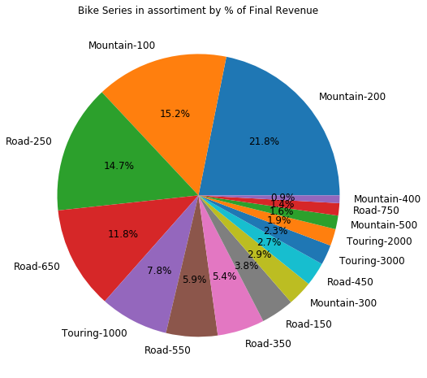

```python
pie_plot(product_series_view, 'final_order_price', 'product_series',
        'Bike Series in assortiment by % of Final Revenue')
```

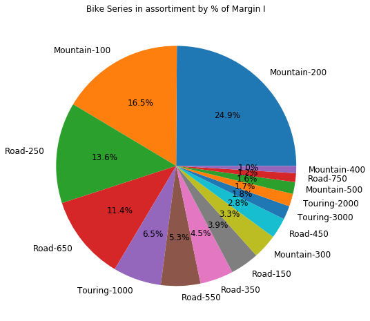

```python
pie_plot(product_series_view, 'order_margin_1', 'product_series',
        'Bike Series in assortiment by % of Margin I')
```

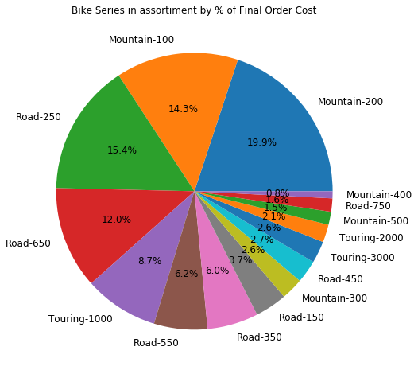

```python
pie_plot(product_series_view, 'order_cost', 'product_series',
        'Bike Series in assortiment by % of Final Order Cost')
```

#### Other sub categories

```python
### Looking at all else but bikes
other_sub_products = sub_product_view.loc[~sub_product_view['product_sub_category'].isin(['Road Bikes',
                                                                                        'Mountain Bikes',
                                                                                        'Touring Bikes'])]
```

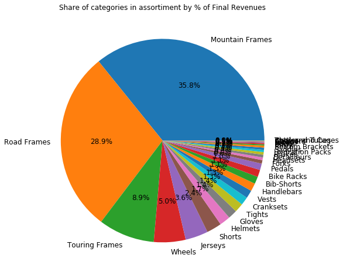

```python
pie_plot(other_sub_products, 'final_order_price', 'product_sub_category',
        'Share of categories in assortiment by % of Final Revenues')
```

```python
### Revenues by sub product categories
sub_product_view_rec = df_1.groupby('product_sub_category_rec').agg({'order_qty':'count', 'final_order_price':'sum',
                                                                 'order_cost':'sum', 'order_margin_1':'sum',
                                             'order_margin_2': 'sum'}).reset_index().sort_values(by = 'final_order_price',
                                                                                        ascending = False)
```

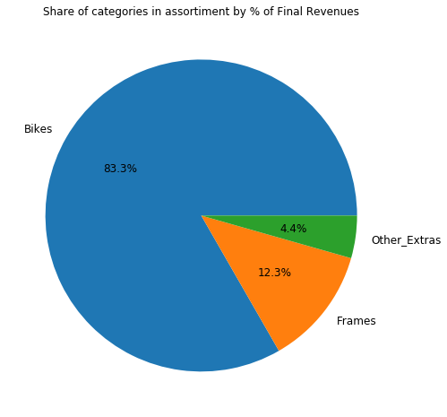

```python
pie_plot(sub_product_view_rec, 'final_order_price', 'product_sub_category_rec',
        'Share of categories in assortiment by % of Final Revenues')
```

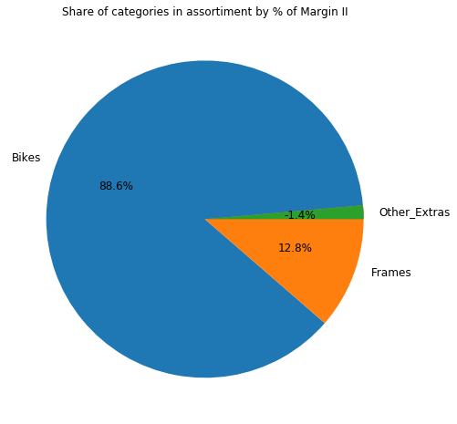

```python
### This does not make much sense as a visualization as it shows a negative 1.4% because Margin 2 overall has been negative
## for other Extras
pie_plot(sub_product_view_rec, 'order_margin_2', 'product_sub_category_rec',
        'Share of categories in assortiment by % of Margin II')
```

```python
df_1[['product_name','unit_price', 'unit_price_discount',
      'unit_final_price', 'order_qty', 'final_order_price', 'order_discount']].loc[df_1['product_name']==example].drop_duplicates()
```

|  | product_name | unit_price | unit_price_discount | unit_final_price | order_qty | final_order_price | order_discount |
| --- | --- | --- | --- | --- | --- | --- | --- |
| 5 | Mountain-100 Silver, 44 | 3399.99 | 0.00 | 3399.99 | 2 | 6799.98 | 0.0 |
| 21 | Mountain-100 Silver, 44 | 3399.99 | 0.00 | 3399.99 | 1 | 3399.99 | 0.0 |
| 374 | Mountain-100 Silver, 44 | 3399.99 | 0.00 | 3399.99 | 4 | 13599.96 | 0.0 |
| 511 | Mountain-100 Silver, 44 | 3399.99 | 0.02 | 3331.99 | 12 | 39983.88 | 816.0 |
| 574 | Mountain-100 Silver, 44 | 3399.99 | 0.00 | 3399.99 | 5 | 16999.95 | 0.0 |
| 666 | Mountain-100 Silver, 44 | 3399.99 | 0.00 | 3399.99 | 3 | 10199.97 | 0.0 |
| 1182 | Mountain-100 Silver, 44 | 3399.99 | 0.00 | 3399.99 | 7 | 23799.93 | 0.0 |
| 1215 | Mountain-100 Silver, 44 | 3399.99 | 0.00 | 3399.99 | 8 | 27199.92 | 0.0 |
| 1269 | Mountain-100 Silver, 44 | 3399.99 | 0.00 | 3399.99 | 6 | 20399.94 | 0.0 |
| 2039 | Mountain-100 Silver, 44 | 3399.99 | 0.00 | 3399.99 | 10 | 33999.90 | 0.0 |
| 5984 | Mountain-100 Silver, 44 | 3399.99 | 0.35 | 2209.99 | 1 | 2209.99 | 1190.0 |
| 6144 | Mountain-100 Silver, 44 | 3399.99 | 0.35 | 2209.99 | 2 | 4419.98 | 2380.0 |
| 6357 | Mountain-100 Silver, 44 | 3399.99 | 0.35 | 2209.99 | 3 | 6629.97 | 3570.0 |
| 6522 | Mountain-100 Silver, 44 | 3399.99 | 0.35 | 2209.99 | 5 | 11049.95 | 5950.0 |

### Function to aggregate in given groupings incl. at least a ideally monthly view

```python
def aggregate_grouped_df(df_name, grouping):

    """
    In the grouping variable, if using more than 1, please enter 'order_month' or the relevant time period first
    for the relevant delta columns to be created

    """
    ## Nice to add in the future - function that rearranges the variables in the list to put the time_bound variable first
    new_df = df_name.groupby(grouping).agg({'order_qty':[np.mean, np.sum], 'sales_order_number':'count',
                                  'order_price':[np.mean, np.sum], 'final_order_price':[np.mean, np.sum],
                                  'order_cost':[np.mean, np.sum],'order_freight_cost':[np.mean, np.sum],
                                  'order_margin_1':'sum', 'order_margin_2':'sum',
                                  'unit_price':'mean', 'unit_cost':'mean'}).reset_index()



    #### Converting MultiIndex to a conventional index for ease of use
    ### Renaming columns for ease of use

    new_df.columns = new_df.columns.to_flat_index()
    new_df = new_df.rename(columns={('order_month',''):'order_month',
                  ('order_qty', 'mean'):'items_ordered_mean', ('order_qty', 'sum'):'items_ordered_sum',
                  ('sales_order_number', 'count'): 'unique_orders', ('order_price', 'mean'): 'revenue_mean',
                  ('order_price', 'sum'): 'revenue_sum',    ('final_order_price', 'mean'): 'final_revenue_mean',
                  ('final_order_price', 'sum'): 'final_revenue_sum', ('order_cost', 'mean'): 'order_cost_mean',
                  ('order_cost', 'sum'): 'order_cost_sum',  ('order_freight_cost', 'mean'): 'order_freight_cost_mean',
                  ('order_freight_cost', 'sum') : 'order_freight_cost_sum',
                  ('order_margin_1', 'sum'): 'order_margin_1_sum', ('order_margin_2', 'sum') : 'order_margin_2_sum',
                  ('unit_price', 'mean'):'unit_price_mean', ('unit_cost', 'mean'):'unit_cost_mean'})

    if isinstance(grouping, list):

        for element in grouping[1:]:

#            renaming every other column in the grouping
            new_df = new_df.rename(columns={(element, ''):element})

        grouping_use = grouping[1:]
        if len(grouping_use) == 1:
            grouping_use = str(grouping_use).strip("[]''")
    else:
        grouping_use = grouping

    ## Calculating Delta columns
    new_df['revenue_sum_delta'] = new_df.groupby(grouping_use)['revenue_sum'].diff()
    new_df['revenue_sum_delta_pct'] = new_df.groupby(grouping_use)['revenue_sum'].pct_change()

    new_df['final_revenue_sum_delta'] = new_df.groupby(grouping_use)['final_revenue_sum'].diff()
    new_df['final_revenue_sum_delta_pct'] = new_df.groupby(grouping_use)['final_revenue_sum'].pct_change()

    new_df['order_cost_sum_delta'] = new_df.groupby(grouping_use)['order_cost_sum'].diff()
    new_df['order_cost_sum_delta_pct'] = new_df.groupby(grouping_use)['order_cost_sum'].pct_change()

    new_df['order_freight_cost_sum_delta'] = new_df.groupby(grouping_use)['order_freight_cost_sum'].diff()
    new_df['order_freight_cost_sum_delta_pct'] = new_df.groupby(grouping_use)['order_freight_cost_sum'].pct_change()

    new_df['order_margin_1_sum_delta'] = new_df.groupby(grouping_use)['order_margin_1_sum'].diff()
    new_df['order_margin_1_sum_delta_pct'] = new_df.groupby(grouping_use)['order_margin_1_sum'].pct_change()

    new_df['order_margin_2_sum_delta'] = new_df.groupby(grouping_use)['order_margin_2_sum'].diff()
    new_df['order_margin_2_sum_delta_pct'] = new_df.groupby(grouping_use)['order_margin_2_sum'].pct_change()

    ## Calculating other possibly relevant columns
    new_df['order_discount_sum'] = new_df['final_revenue_sum'] - new_df['revenue_sum']

    new_df['cogs/revenue'] = new_df['order_cost_sum']/new_df['revenue_sum']
    new_df['cogs/final_revenue'] = new_df['order_cost_sum']/new_df['final_revenue_sum']

    new_df['order_cm1%'] = new_df['order_margin_1_sum']/new_df['revenue_sum']
    new_df['order_cm2%'] = new_df['order_margin_2_sum']/new_df['revenue_sum']

    return new_df
```

### Only monthly grouping

```python
basic_monthly_view = aggregate_grouped_df(df_1, 'order_month')
```

```python
basic_monthly_view.head(5)
```

|  | order_month | items_ordered_mean | items_ordered_sum | unique_orders | revenue_mean | revenue_sum | final_revenue_mean | final_revenue_sum | order_cost_mean | order_cost_sum | ... | order_freight_cost_sum_delta_pct | order_margin_1_sum_delta | order_margin_1_sum_delta_pct | order_margin_2_sum_delta | order_margin_2_sum_delta_pct | order_discount_sum | cogs/revenue | cogs/final_revenue | order_cm1% | order_cm2% |
| --- | --- | --- | --- | --- | --- | --- | --- | --- | --- | --- | --- | --- | --- | --- | --- | --- | --- | --- | --- | --- | --- |
| 0 | 2005-07 | 2.224719 | 594 | 267 | 2392.777341 | 638871.55 | 2392.777341 | 638871.55 | 1397.446553 | 3.731182e+05 | ... | NaN | NaN | NaN | NaN | NaN | 0.00 | 0.584027 | 0.584027 | 0.415973 | 0.373335 |
| 1 | 2005-08 | 2.623116 | 1566 | 597 | 3484.801575 | 2080426.54 | 3480.311993 | 2077746.26 | 2000.551108 | 1.194329e+06 | ... | NaN | NaN | NaN | NaN | NaN | -2680.28 | 0.574079 | 0.574819 | 0.424633 | 0.369947 |
| 2 | 2005-09 | 2.532787 | 1236 | 488 | 3349.041434 | 1634332.22 | 3347.498279 | 1633579.16 | 1928.063853 | 9.408952e+05 | ... | NaN | NaN | NaN | NaN | NaN | -753.06 | 0.575706 | 0.575972 | 0.423833 | 0.374492 |
| 3 | 2005-10 | 2.390710 | 875 | 366 | 2846.895929 | 1041963.91 | 2846.847596 | 1041946.22 | 1668.224355 | 6.105701e+05 | ... | NaN | NaN | NaN | NaN | NaN | -17.69 | 0.585980 | 0.585990 | 0.414003 | 0.363497 |
| 4 | 2005-11 | 2.657627 | 2352 | 885 | 3731.788271 | 3302632.62 | 3730.014316 | 3301062.67 | 2160.394293 | 1.911949e+06 | ... | NaN | NaN | NaN | NaN | NaN | -1569.95 | 0.578917 | 0.579192 | 0.420608 | 0.364375 |

5 rows × 33 columns

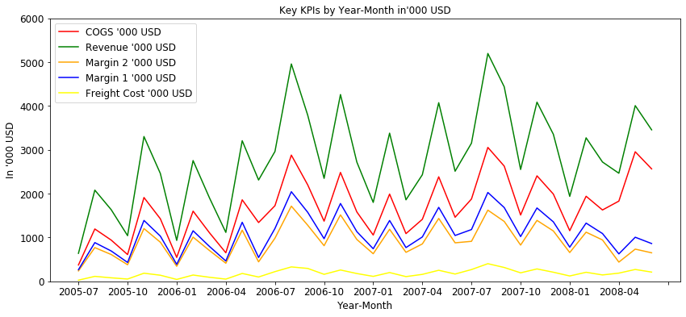

```python
plt.figure(figsize = (14,6))

## setting every third Year-Month as ticker to not overcrowd the graph
ax = plt.axes()
ax.xaxis.set_major_locator(ticker.MultipleLocator(3))

plt.plot(basic_monthly_view['order_month'], basic_monthly_view['order_cost_sum']/1000, color = 'r', label = "COGS '000 USD")
plt.plot(basic_monthly_view['order_month'], basic_monthly_view['revenue_sum']/1000, color = 'g',
        label = "Revenue '000 USD")
plt.plot(basic_monthly_view['order_month'], basic_monthly_view['order_margin_2_sum']/1000, color = 'orange',
        label = "Margin 2 '000 USD")
plt.plot(basic_monthly_view['order_month'], basic_monthly_view['order_margin_1_sum']/1000, color = 'blue',
        label = "Margin 1 '000 USD")
plt.plot(basic_monthly_view['order_month'], basic_monthly_view['order_freight_cost_sum']/1000, color = 'yellow',
        label = "Freight Cost '000 USD")
plt.title("Key KPIs by Year-Month in'000 USD", fontsize = 12);
plt.xlabel('Year-Month', fontsize = 12);
plt.legend()
plt.ylabel("In '000 USD", fontsize = 12);
plt.ylim(0, 6000);
```

### The plenty spikes and downs don't let us distill a trend from the developments. Using rolling average below for a clearer graph

```python
basic_monthly_view['rolling_cogs'] = basic_monthly_view['order_cost_sum'].rolling(3).mean()
basic_monthly_view['rolling_revenue'] = basic_monthly_view['revenue_sum'].rolling(3).mean()
basic_monthly_view['rolling_margin_2'] = basic_monthly_view['order_margin_2_sum'].rolling(3).mean()
basic_monthly_view['rolling_margin_1'] = basic_monthly_view['order_margin_1_sum'].rolling(3).mean()
basic_monthly_view['rolling_freight'] = basic_monthly_view['order_freight_cost_sum'].rolling(3).mean()
```

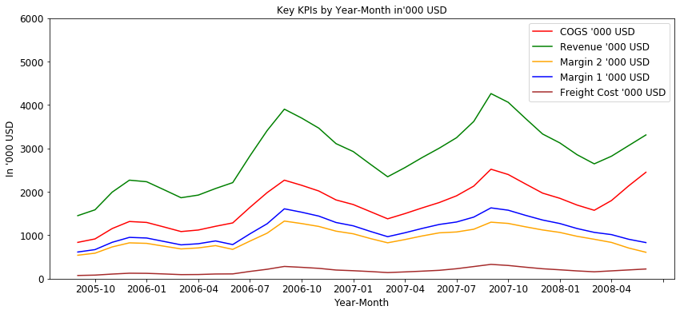

```python
plt.figure(figsize = (14,6))

## setting every third Year-Month as ticker to not overcrowd the graph
ax = plt.axes()
ax.xaxis.set_major_locator(ticker.MultipleLocator(3))

plt.plot(basic_monthly_view['order_month'], basic_monthly_view['rolling_cogs']/1000, color = 'r', label = "COGS '000 USD")
plt.plot(basic_monthly_view['order_month'], basic_monthly_view['rolling_revenue']/1000, color = 'g',
        label = "Revenue '000 USD")
plt.plot(basic_monthly_view['order_month'], basic_monthly_view['rolling_margin_2']/1000, color = 'orange',
        label = "Margin 2 '000 USD")
plt.plot(basic_monthly_view['order_month'], basic_monthly_view['rolling_margin_1']/1000, color = 'blue',
        label = "Margin 1 '000 USD")
plt.plot(basic_monthly_view['order_month'], basic_monthly_view['rolling_freight']/1000, color = 'brown',
        label = "Freight Cost '000 USD")
plt.title("Key KPIs by Year-Month in'000 USD", fontsize = 12);
plt.xlabel('Year-Month', fontsize = 12);
plt.legend()
plt.ylabel("In '000 USD", fontsize = 12);
plt.ylim(0, 6000);
```

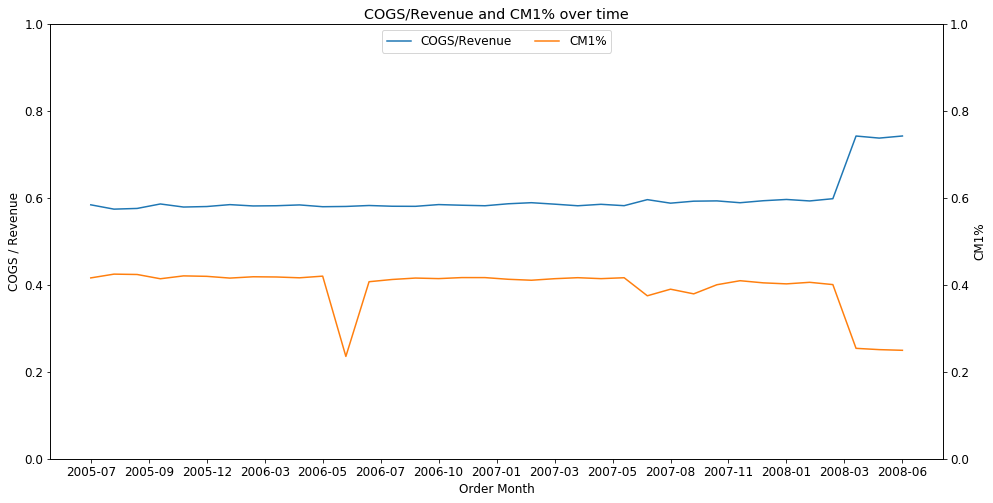

```python
plt.figure(figsize = (16,8))

ax = plt.axes()
ax.xaxis.set_major_locator(ticker.MultipleLocator(2.5))


ax = sns.lineplot('order_month', 'cogs/revenue', data = basic_monthly_view)
a2 = sns.lineplot('order_month', 'order_cm1%', data = basic_monthly_view,
                 palette = ['g','r'])
ax2 = ax.twinx()

plt.title('COGS/Revenue and CM1% over time');
ax.set_ylim(0, 1)
ax.set_xlabel('Order Month', fontsize = 12);
ax.set_ylabel('COGS / Revenue', fontsize = 12);
ax2.set_ylabel('CM1%', fontsize = 12);
ax.legend(['COGS/Revenue', 'CM1%'],loc = 'upper center', ncol = 2, fontsize = 12);
```

```python
monthly_product_view = aggregate_grouped_df(df_1, ['order_month', 'product_category_rec'])
```

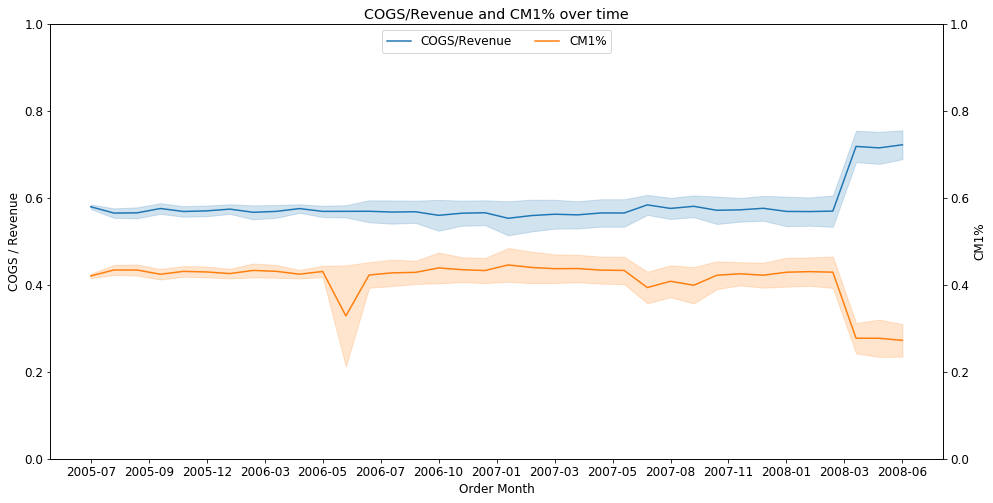

```python
plt.figure(figsize = (16,8))

ax = plt.axes()
ax.xaxis.set_major_locator(ticker.MultipleLocator(2.5))


ax = sns.lineplot('order_month', 'cogs/revenue', data = monthly_product_view)
a2 = sns.lineplot('order_month', 'order_cm1%', data = monthly_product_view,
                 palette = ['g','r'])
ax2 = ax.twinx()

plt.title('COGS/Revenue and CM1% over time');
ax.set_ylim(0, 1)
ax.set_xlabel('Order Month', fontsize = 12);
ax.set_ylabel('COGS / Revenue', fontsize = 12);
ax2.set_ylabel('CM1%', fontsize = 12);
ax.legend(['COGS/Revenue', 'CM1%'],loc = 'upper center', ncol = 2, fontsize = 12);
```

```python
def plot_variable_over_time(df_to_plot, variable_to_plot, variable_ext_name, hue_to_differentiate,
                            hue_ext_name, variable_type='absolute'):
    """
    Function is meant to plot development of variable by month only.
    Variable_type should either be 'percentual' or 'absolute'. It is absolute by default
    """
    plt.figure(figsize = (16,8))

    ax = plt.axes()
    ax.xaxis.set_major_locator(ticker.MultipleLocator(2.5))

    sns.lineplot('order_month', variable_to_plot,
                 hue = hue_to_differentiate, data = df_to_plot)

    plt.title(variable_ext_name + " over time by "+ hue_ext_name);

    if variable_type == 'percentual':
        plt.ylim(0, 1);

    ## enabling a YoY comparison that makes sense
    if hue_to_differentiate == 'order_year':
        ax.xaxis.set_major_locator(ticker.MultipleLocator(1))
        plt.xlim(1, 12)

    plt.xlabel('Order Month', fontsize = 12);
    plt.ylabel(variable_ext_name, fontsize = 12);
```

```python
monthly_product_view['cogs/final_revenue'] = monthly_product_view['order_cost_sum']/monthly_product_view['final_revenue_sum']
```

```python
cogs_to_final_revenue_view = monthly_product_view[['order_month', 'product_category_rec', 'cogs/final_revenue']]
```

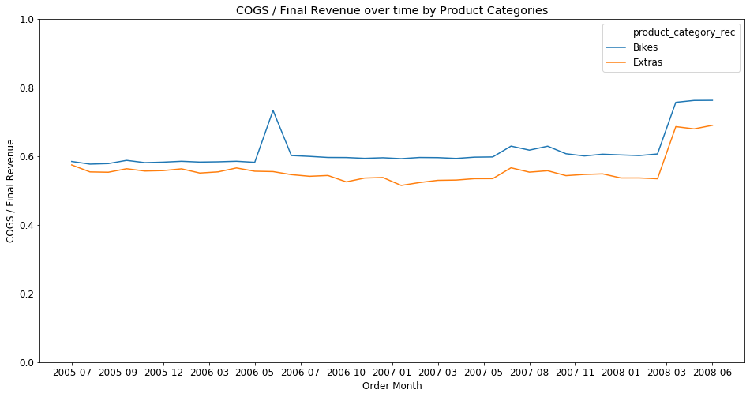

```python
plot_variable_over_time(monthly_product_view, 'cogs/final_revenue', 'COGS / Final Revenue',
                       'product_category_rec', 'Product Categories', variable_type = 'percentual')
```

### Sub-products view for Bikes

```python
bikes_df_1 = df_1.loc[df_1['product_category']=='Bikes']
monthly_bike_subproducts_view = aggregate_grouped_df(bikes_df_1, ['order_month', 'product_sub_category'])
```

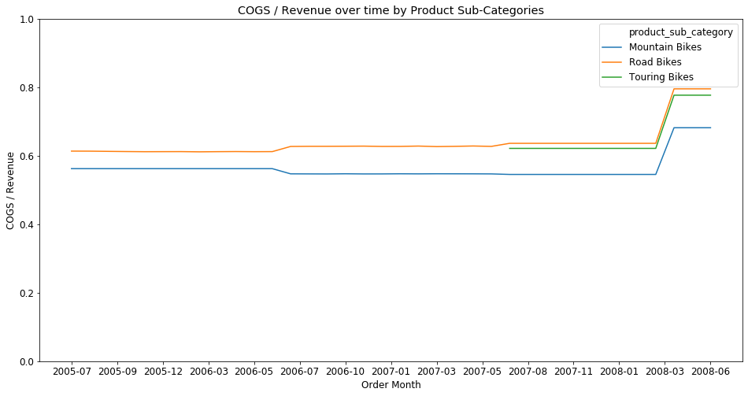

```python
plot_variable_over_time(monthly_bike_subproducts_view, 'cogs/revenue', 'COGS / Revenue',
                       'product_sub_category', 'Product Sub-Categories', variable_type = 'percentual')
```

```python
df_1['product_sub_category_rec'] = np.where(df_1['product_sub_category'].str.contains(' Frames'), 'Frames',
                                   np.where(df_1['product_sub_category'].str.contains(' Bikes'), 'Bikes', 'Other_Extras'))
```

```python
monthly_subproducts_view = aggregate_grouped_df(df_1, ['order_month', 'product_sub_category_rec'])
```

```python
monthly_subproducts_view['product_sub_category_rec']
```

```
0             Bikes
1            Frames
2      Other_Extras
3             Bikes
4            Frames
           ...
103          Frames
104    Other_Extras
105           Bikes
106          Frames
107    Other_Extras
Name: product_sub_category_rec, Length: 108, dtype: object
```

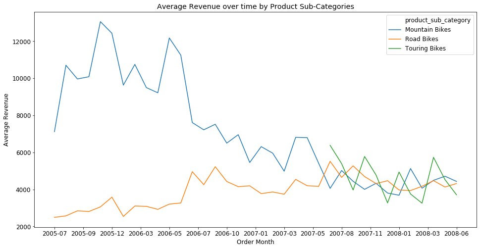

```python
plot_variable_over_time(monthly_bike_subproducts_view, 'revenue_mean', 'Average Revenue',
                       'product_sub_category', 'Product Sub-Categories')
```

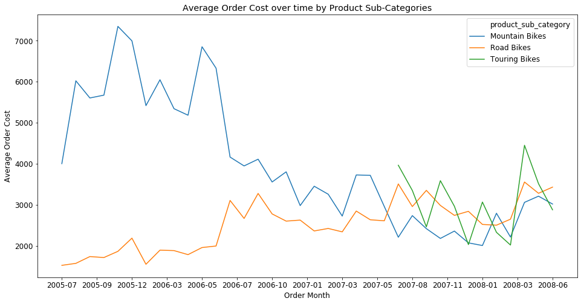

```python
plot_variable_over_time(monthly_bike_subproducts_view, 'order_cost_mean', 'Average Order Cost',
                       'product_sub_category', 'Product Sub-Categories')
```

Average Order cost increased last 3 months of 2008. Could mean that per order the amount of items ordered were higher

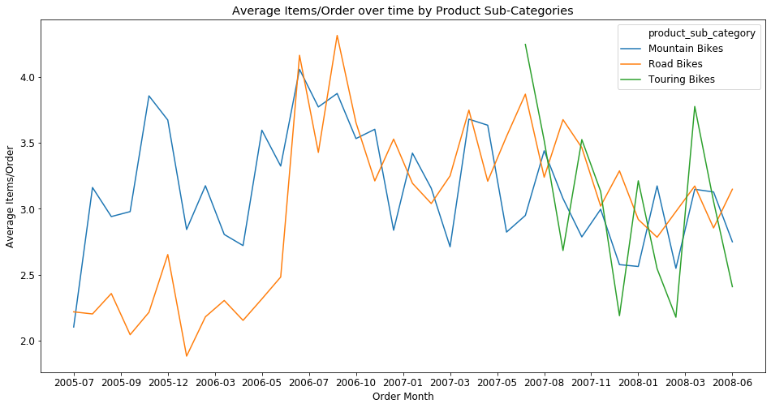

```python
plot_variable_over_time(monthly_bike_subproducts_view, 'items_ordered_mean', 'Average Items/Order',
                       'product_sub_category', 'Product Sub-Categories')
```

Slightly decreasing pattern but no clear direction. Need a more extensive basket analysis to dig further

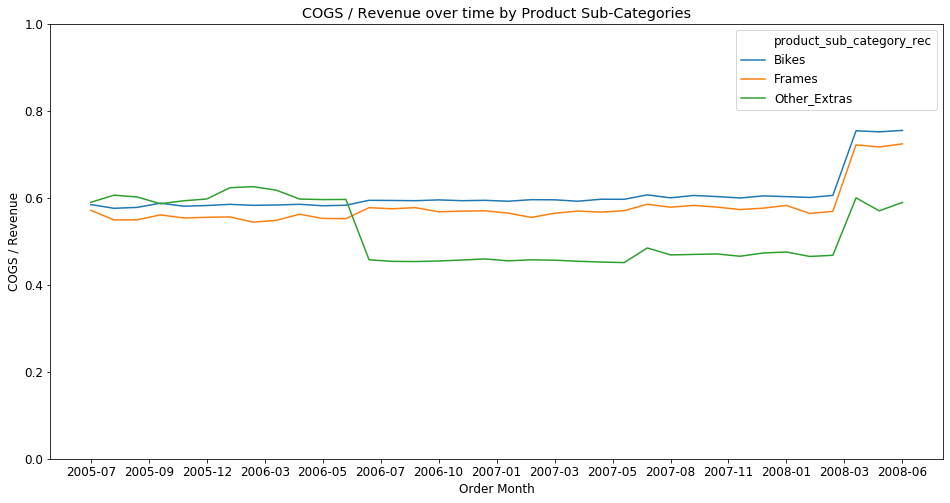

```python
plot_variable_over_time(monthly_subproducts_view, 'cogs/revenue', 'COGS / Revenue',
                       'product_sub_category_rec', 'Product Sub-Categories', variable_type = 'percentual')
```

```python
monthly_subproducts_view.columns
```

```
Index(['order_month', 'product_sub_category_rec', 'items_ordered_mean',
       'items_ordered_sum', 'unique_orders', 'revenue_mean', 'revenue_sum',
       'final_revenue_mean', 'final_revenue_sum', 'order_cost_mean',
       'order_cost_sum', 'order_freight_cost_mean', 'order_freight_cost_sum',
       'order_margin_1_sum', 'order_margin_2_sum', 'unit_price_mean',
       'unit_cost_mean', 'revenue_sum_delta', 'revenue_sum_delta_pct',
       'final_revenue_sum_delta', 'final_revenue_sum_delta_pct',
       'order_cost_sum_delta', 'order_cost_sum_delta_pct',
       'order_freight_cost_sum_delta', 'order_freight_cost_sum_delta_pct',
       'order_margin_1_sum_delta', 'order_margin_1_sum_delta_pct',
       'order_margin_2_sum_delta', 'order_margin_2_sum_delta_pct',
       'order_discount_sum', 'cogs/revenue', 'cogs/final_revenue',
       'order_cm1%', 'order_cm2%'],
      dtype='object')
```

```python
monthly_subproducts_view['order_margin_1_sum']/1000
```

```
0      250.448703
1       12.798740
2        2.505877
3      801.902671
4       75.746451
          ...
103    162.704857
104     87.926145
105    654.050429
106    136.850036
107     71.228588
Name: order_margin_1_sum, Length: 108, dtype: float64
```

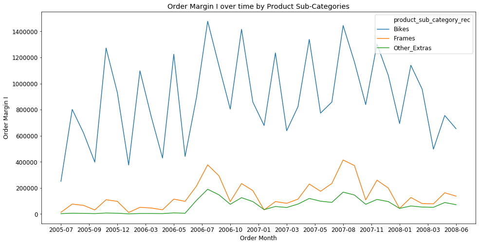

```python
plot_variable_over_time(monthly_subproducts_view, 'order_margin_1_sum', 'Order Margin I',
                                                  'product_sub_category_rec', 'Product Sub-Categories')
```

#### By applying a moving average we can get a better picture of the development by getting rid of the MoM fluctuations aiming to show the trend

```python
## For the moving average to work I, for yet to me unknown reasons in contrast to other groupby agg functions,
## had to sort by the relevant aggregating functions
rolling_test = monthly_subproducts_view.sort_values(by=['product_sub_category_rec', 'order_month'], ascending = True)
```

```python
rolling_test['margin_1_sum_rolling_mean'] = rolling_test.groupby(['product_sub_category_rec'])['order_margin_1_sum'].rolling(3).mean().values
rolling_test['margin_2_sum_rolling_mean'] = rolling_test.groupby(['product_sub_category_rec'])['order_margin_2_sum'].rolling(3).mean().values
```

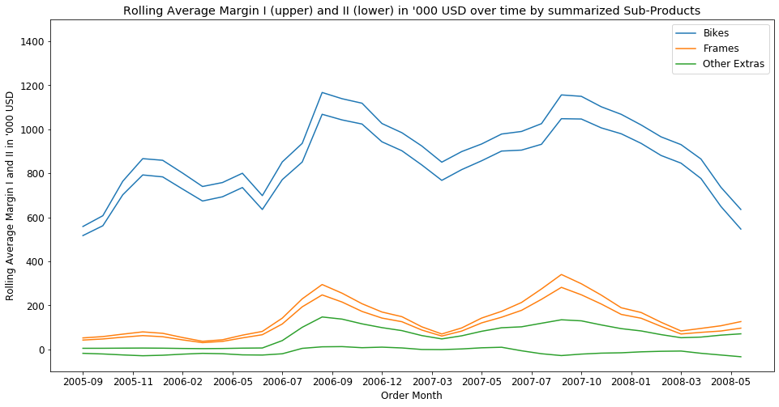

```python
# fig, ax = plt.subplots(1,1)
# fig, ax1 = plt.subplots(figsize = (16,8))
plt.figure(figsize = (16,8))

ax = plt.axes()
ax.xaxis.set_major_locator(ticker.MultipleLocator(2.5))

# ax2 = ax1.twinx()
### What we could further add

sns.lineplot('order_month', rolling_test['margin_1_sum_rolling_mean']/1000,
             hue = 'product_sub_category_rec', data = rolling_test)

sns.lineplot('order_month', rolling_test['margin_2_sum_rolling_mean']/1000,
             hue = 'product_sub_category_rec', data = rolling_test)


plt.title("Rolling Average Margin I (upper) and II (lower) in '000 USD over time by summarized Sub-Products");
# plt.ylim(0, 1)
plt.ylim(-100, 1500)
plt.xlabel('Order Month', fontsize = 12);
plt.ylabel("Rolling Average Margin I and II in '000 USD", fontsize = 12);
plt.legend(['Bikes', 'Frames', 'Other Extras']);
plt.show()
```

Here we can clearly see that indeed Margin I and II have decreased over the last 3 months substantially

```python
### Sense check for the new added colums
rolling_test
```

|  | order_month | product_sub_category_rec | items_ordered_mean | items_ordered_sum | unique_orders | revenue_mean | revenue_sum | final_revenue_mean | final_revenue_sum | order_cost_mean | ... | order_margin_1_sum_delta_pct | order_margin_2_sum_delta | order_margin_2_sum_delta_pct | order_discount_sum | cogs/revenue | cogs/final_revenue | order_cm1% | order_cm2% | margin_1_sum_rolling_mean | margin_2_sum_rolling_mean |
| --- | --- | --- | --- | --- | --- | --- | --- | --- | --- | --- | --- | --- | --- | --- | --- | --- | --- | --- | --- | --- | --- |
| 0 | 2005-07 | Bikes | 2.183007 | 334 | 153 | 3940.549150 | 602904.02 | 3940.549150 | 602904.02 | 2303.629525 | ... | NaN | NaN | NaN | 0.00 | 0.584596 | 0.584596 | 0.415404 | 0.388445 | NaN | NaN |
| 3 | 2005-08 | Bikes | 2.584098 | 845 | 327 | 5803.005474 | 1897582.79 | 5794.915260 | 1894937.29 | 3342.613513 | ... | 2.201864 | 505983.886700 | 2.160526 | -2645.50 | 0.576014 | 0.576818 | 0.422592 | 0.390064 | NaN | NaN |
| 6 | 2005-09 | Bikes | 2.583333 | 682 | 264 | 5592.150985 | 1476327.86 | 5589.338485 | 1475585.36 | 3232.969030 | ... | -0.224243 | -163987.940200 | -0.221552 | -742.50 | 0.578126 | 0.578417 | 0.421371 | 0.390286 | 558144.303333 | 516854.715600 |
| 9 | 2005-10 | Bikes | 2.243243 | 498 | 222 | 4345.048739 | 964600.82 | 4345.048739 | 964600.82 | 2554.032711 | ... | -0.360847 | -207809.482800 | -0.360661 | 0.00 | 0.587803 | 0.587803 | 0.412197 | 0.381900 | 607196.588467 | 561583.536833 |
| 12 | 2005-11 | Bikes | 2.678917 | 1385 | 517 | 5879.464197 | 3039682.99 | 5876.461296 | 3038130.49 | 3415.065368 | ... | 2.200513 | 794093.230700 | 2.155629 | -1552.50 | 0.580846 | 0.581143 | 0.418643 | 0.382433 | 764076.263100 | 702348.806067 |
| ... | ... | ... | ... | ... | ... | ... | ... | ... | ... | ... | ... | ... | ... | ... | ... | ... | ... | ... | ... | ... | ... |
| 95 | 2008-02 | Other_Extras | 3.757407 | 2029 | 540 | 214.336444 | 115741.68 | 213.606333 | 115347.42 | 99.741988 | ... | 0.435937 | -3360.181100 | 0.361422 | -394.26 | 0.465352 | 0.466943 | 0.531241 | -0.109358 | 66502.411400 | -9310.796900 |
| 98 | 2008-03 | Other_Extras | 3.760776 | 1745 | 464 | 216.336056 | 100379.93 | 215.592996 | 100035.15 | 101.233927 | ... | -0.137007 | 10017.266800 | -0.791423 | -344.78 | 0.467948 | 0.469560 | 0.528618 | -0.026300 | 52456.437400 | -8198.144100 |
| 101 | 2008-04 | Other_Extras | 5.015238 | 2633 | 525 | 254.382324 | 133550.72 | 250.291010 | 131402.78 | 152.647443 | ... | -0.033917 | -37230.858450 | 14.102456 | -2147.94 | 0.600071 | 0.609880 | 0.383846 | -0.298545 | 55270.742283 | -18389.401683 |
| 104 | 2008-05 | Other_Extras | 4.465558 | 3760 | 842 | 247.077067 | 208038.89 | 245.304192 | 206546.13 | 140.878842 | ... | 0.715201 | 3600.121775 | -0.090295 | -1492.76 | 0.570182 | 0.574303 | 0.422643 | -0.174346 | 64083.875158 | -26260.558308 |
| 107 | 2008-06 | Other_Extras | 4.110533 | 3161 | 769 | 228.317373 | 175576.06 | 227.234096 | 174743.02 | 134.609145 | ... | -0.189904 | 10105.643225 | -0.278617 | -833.04 | 0.589570 | 0.592381 | 0.405685 | -0.149024 | 70139.201708 | -34102.256125 |

108 rows × 36 columns

```python
monthly_bikes_series_view = aggregate_grouped_df(df_1.loc[df_1['product_category']=='Bikes'],
                                                   ['order_month', 'product_series'])
```

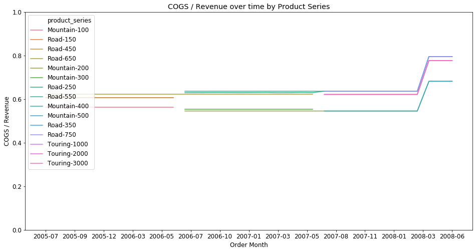

```python
plot_variable_over_time(monthly_bikes_series_view, 'cogs/revenue', 'COGS / Revenue',
                                                  'product_series', 'Product Series', variable_type = 'percentual')
```

```python
mountain_monthly_bikes_series_view = monthly_bikes_series_view.loc[monthly_bikes_series_view['product_series'].str.contains('Mountain')]
road_monthly_bikes_series_view = monthly_bikes_series_view.loc[monthly_bikes_series_view['product_series'].str.contains('Road')]
touring_monthly_bikes_series_view = monthly_bikes_series_view.loc[monthly_bikes_series_view['product_series'].str.contains('Touring')]
```

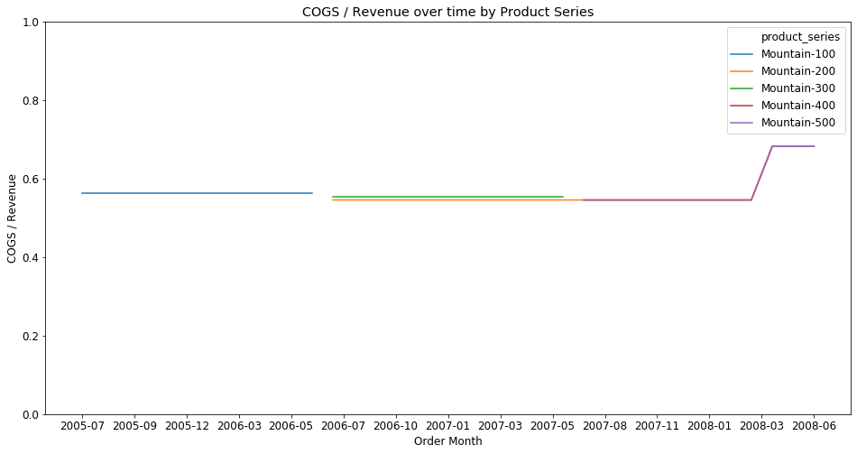

```python
plot_variable_over_time(mountain_monthly_bikes_series_view, 'cogs/revenue', 'COGS / Revenue',
                                                  'product_series', 'Product Series', variable_type = 'percentual')
```

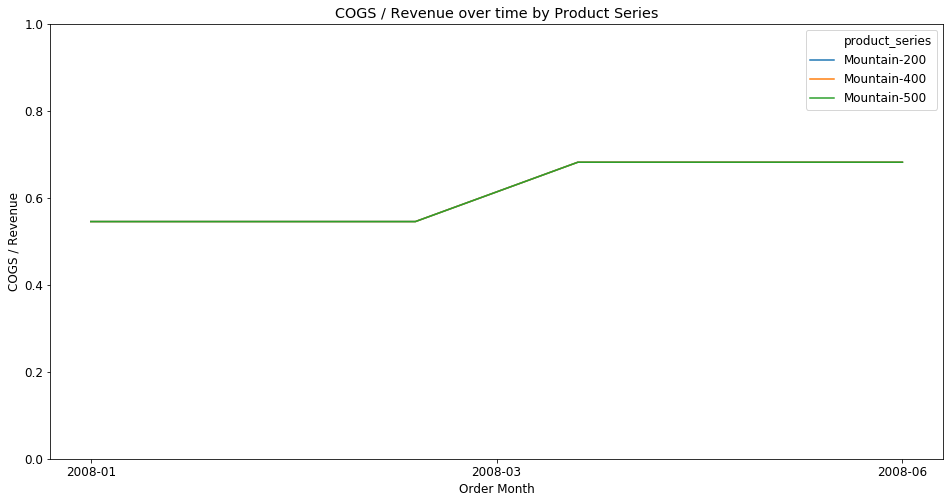

```python
plot_variable_over_time(mountain_monthly_bikes_series_view.loc[mountain_monthly_bikes_series_view['order_month']>='2008-01'],
                         'cogs/revenue', 'COGS / Revenue', 'product_series', 'Product Series', variable_type = 'percentual')
```

## Unit Economics

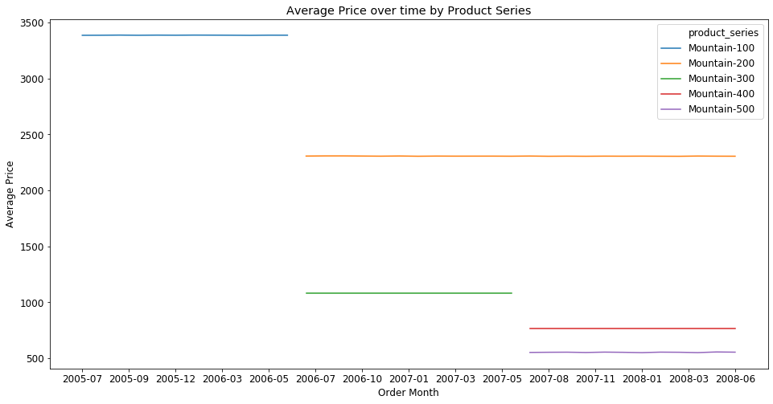

```python
### Average price of Mountain 200, 400 and 500 has not changed in 2008 at all
plot_variable_over_time(mountain_monthly_bikes_series_view, 'unit_price_mean', 'Average Price',
                        'product_series', 'Product Series')
```

## Example: Unit Price and Unit Cost for Mountain 200

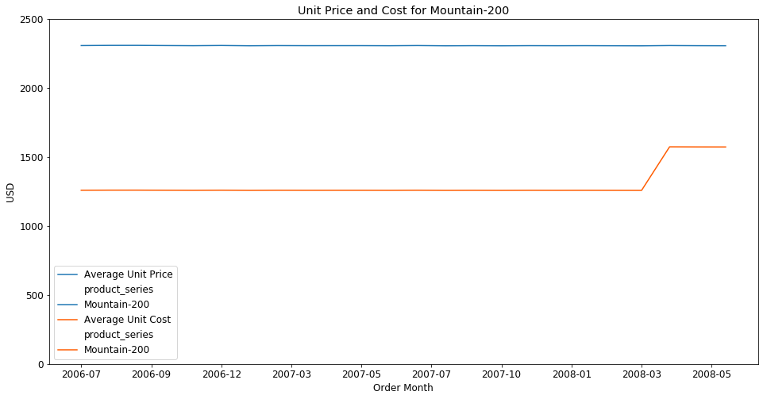

```python
plt.figure(figsize = (16,8))

ax = plt.axes()
ax.xaxis.set_major_locator(ticker.MultipleLocator(2.5))


sns.lineplot('order_month', mountain_monthly_bikes_series_view['unit_price_mean'],
             hue = 'product_series', label = 'Average Unit Price',
             data = monthly_bikes_series_view.loc[monthly_bikes_series_view['product_series']=='Mountain-200'])

sns.lineplot('order_month', mountain_monthly_bikes_series_view['unit_cost_mean'],
             hue = 'product_series', palette = 'hot', label = 'Average Unit Cost',
             data = monthly_bikes_series_view.loc[monthly_bikes_series_view['product_series']=='Mountain-200'])


plt.title("Unit Price and Cost for Mountain-200");
plt.ylim(0, 2500)

plt.xlabel('Order Month', fontsize = 12);
plt.ylabel("USD", fontsize = 12);
plt.show()
```

##### Room to automate these two line graphs through a function given more time

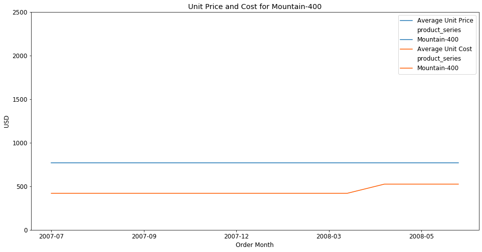

```python
plt.figure(figsize = (16,8))

ax = plt.axes()
ax.xaxis.set_major_locator(ticker.MultipleLocator(2.5))


sns.lineplot('order_month', mountain_monthly_bikes_series_view['unit_price_mean'],
             hue = 'product_series', label = 'Average Unit Price',
             data = mountain_monthly_bikes_series_view.loc[mountain_monthly_bikes_series_view['product_series']=='Mountain-400'])

sns.lineplot('order_month', mountain_monthly_bikes_series_view['unit_cost_mean'],
             hue = 'product_series', palette = 'hot', label = 'Average Unit Cost',
             data = mountain_monthly_bikes_series_view.loc[mountain_monthly_bikes_series_view['product_series']=='Mountain-400'])


plt.title("Unit Price and Cost for Mountain-400");
plt.ylim(0, 2500)

plt.xlabel('Order Month', fontsize = 12);
plt.ylabel("USD", fontsize = 12);
plt.show()
```

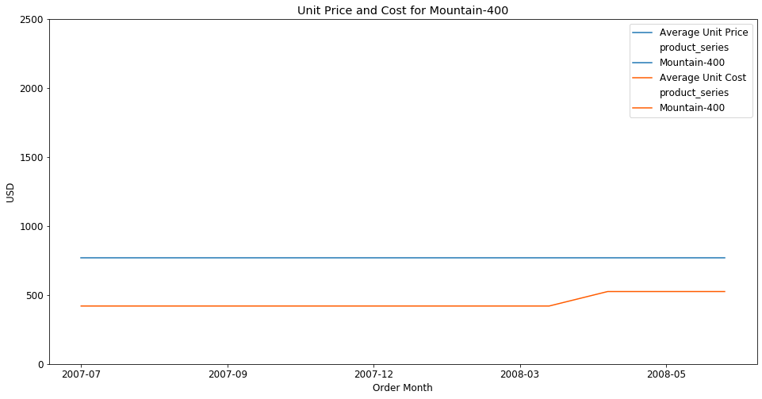

```python
plt.figure(figsize = (16,8))

ax = plt.axes()
ax.xaxis.set_major_locator(ticker.MultipleLocator(2.5))


sns.lineplot('order_month', mountain_monthly_bikes_series_view['unit_price_mean'],
             hue = 'product_series', label = 'Average Unit Price',
             data = mountain_monthly_bikes_series_view.loc[mountain_monthly_bikes_series_view['product_series']=='Mountain-400'])

sns.lineplot('order_month', mountain_monthly_bikes_series_view['unit_cost_mean'],
             hue = 'product_series', palette = 'hot', label = 'Average Unit Cost',
             data = mountain_monthly_bikes_series_view.loc[mountain_monthly_bikes_series_view['product_series']=='Mountain-400'])


plt.title("Unit Price and Cost for Mountain-400");
plt.ylim(0, 2500)
plt.xlabel('Order Month', fontsize = 12);
plt.ylabel("USD", fontsize = 12);
plt.show()

## The legend can be further simplified
```

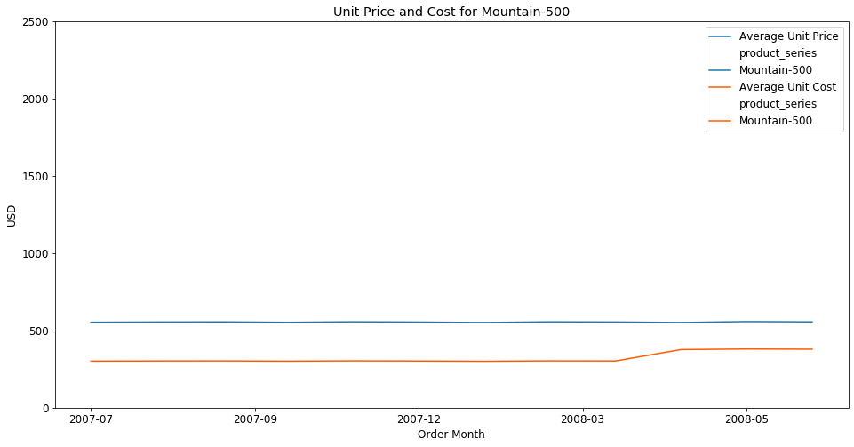

```python
# fig, ax = plt.subplots(1,1)
# fig, ax1 = plt.subplots(figsize = (16,8))
plt.figure(figsize = (16,8))

ax = plt.axes()
ax.xaxis.set_major_locator(ticker.MultipleLocator(2.5))


sns.lineplot('order_month', mountain_monthly_bikes_series_view['unit_price_mean'],
             hue = 'product_series', label = 'Average Unit Price',
             data = mountain_monthly_bikes_series_view.loc[mountain_monthly_bikes_series_view['product_series']=='Mountain-500'])

sns.lineplot('order_month', mountain_monthly_bikes_series_view['unit_cost_mean'],
             hue = 'product_series', palette = 'hot', label = 'Average Unit Cost',
             data = mountain_monthly_bikes_series_view.loc[mountain_monthly_bikes_series_view['product_series']=='Mountain-500'])


plt.title("Unit Price and Cost for Mountain-500");
plt.ylim(0, 2500)

plt.xlabel('Order Month', fontsize = 12);
plt.ylabel("USD", fontsize = 12);
plt.show()

## The legend can be further simplified
```

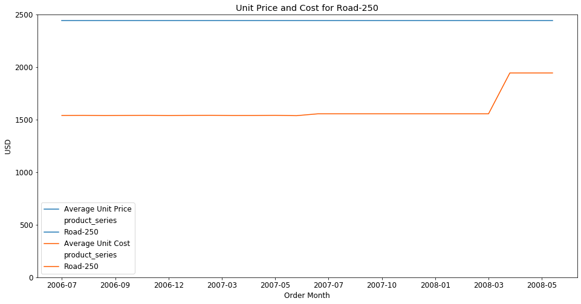

```python
# fig, ax = plt.subplots(1,1)
# fig, ax1 = plt.subplots(figsize = (16,8))
plt.figure(figsize = (16,8))

ax = plt.axes()
ax.xaxis.set_major_locator(ticker.MultipleLocator(2.5))


sns.lineplot('order_month', monthly_bikes_series_view['unit_price_mean'],
             hue = 'product_series', label = 'Average Unit Price',
             data = monthly_bikes_series_view.loc[monthly_bikes_series_view['product_series']=='Road-250'])

sns.lineplot('order_month', monthly_bikes_series_view['unit_cost_mean'],
             hue = 'product_series', palette = 'hot', label = 'Average Unit Cost',
             data = monthly_bikes_series_view.loc[monthly_bikes_series_view['product_series']=='Road-250'])


plt.title("Unit Price and Cost for Road-250");
plt.ylim(0, 2500)
# plt.ylim(-100, 1000)
# plt.ylim(0)
plt.xlabel('Order Month', fontsize = 12);
plt.ylabel("USD", fontsize = 12);
plt.show()

## The legend can be further simplified
```